Go Back

# Belgium

Andre-Ignace Ghonda Lukoki

Dec 19th, 2023

## Set-up

This page was made using Rmarkdown and knitr.

## Research

I plan on investigating the relationship between Exports and Output and more specifically the impact of exports on the GDP growth. This is mainly because Belgium heavily relies on international trade.

## Variables

**Exploratory Data Analysis**

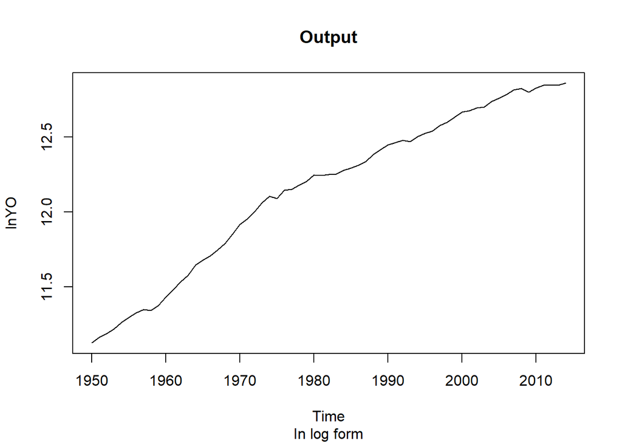

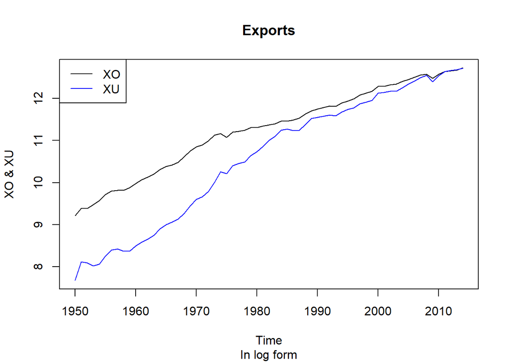

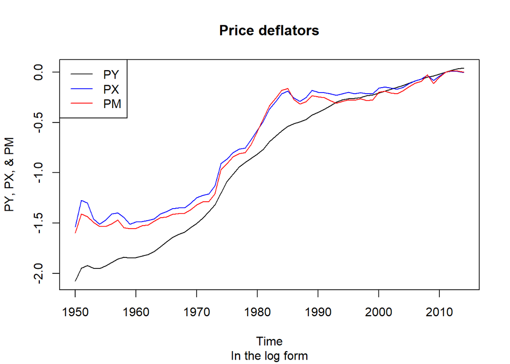

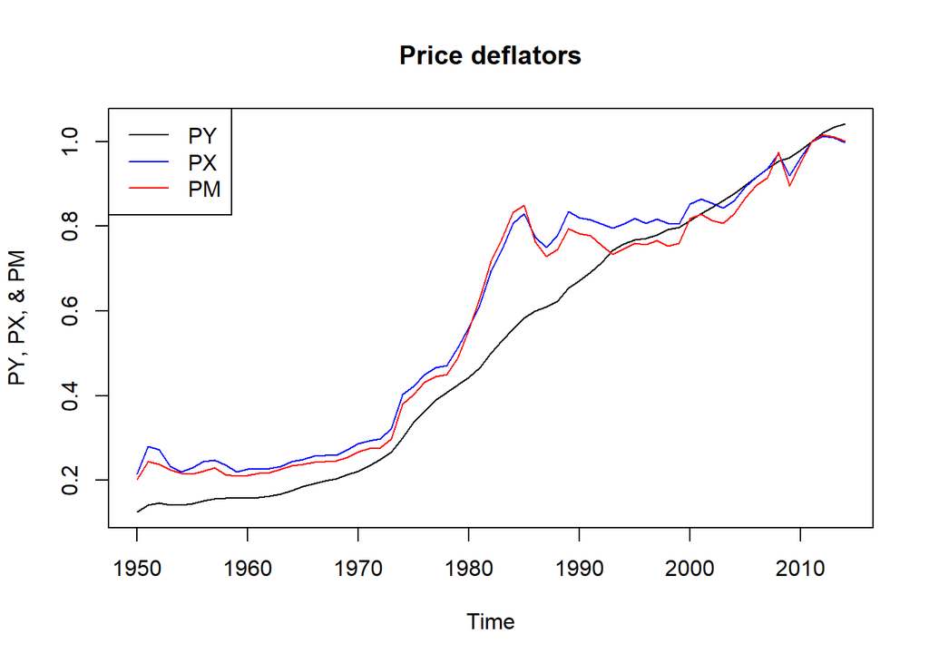

It also seems from the plot of price deflators in standard form that the price deflator of GDP can be used as an approximation for the inflation rate.

This variable is quite useful because Belgium is one of the few countries that employs a system of automatic wage indexation (meaning that wages are automatically increased to match the rate of inflation). This policy, however, has time and time again been criticized for being one of the reason for the lack of competitiveness of Belgian wages and firms in the global economy.

Given that Belgium heavily relies on international trade due to its status as a small, rich and open economy, it is a must that Belgian companies are not only able to provide quality products but also products at a competitive price. If Belgian goods are too expensive then foreign consumers will choose to consume other cheaper alternatives. One aspect of the price of a good or service produced in any economy is the cost of labor (or wage).

## Variables chosen

This research project will focus on the impact of Exports $XO$ on Output $YO$.

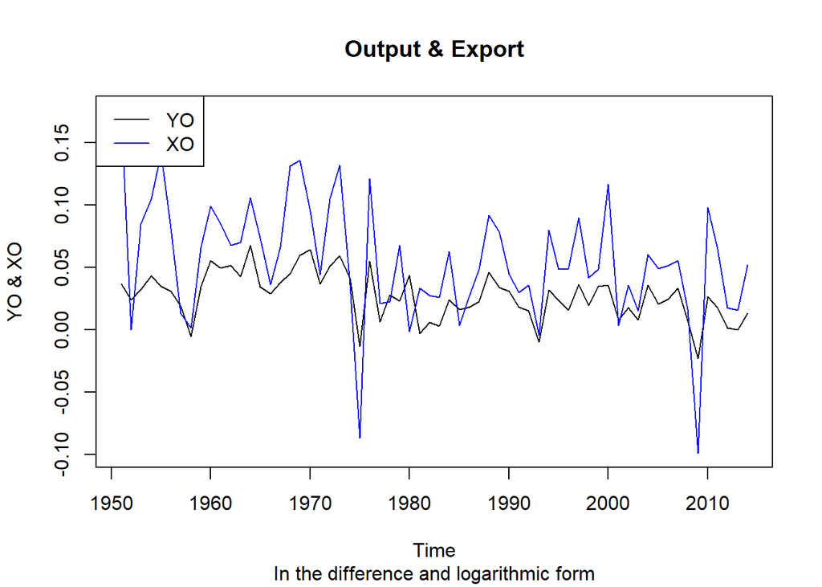

**Visual Inspection of Trends - Logarithm**

**Output**

Consider the following model for $lnYO_{t}$ with a trend:

$$\tag{1} lnYO_{t} = \beta_{0} + \beta_{1} t + u_{t}$$

```
##
## Call:
## lm(formula = lnYO_0 ~ trend)
##
## Residuals:
##       Min        1Q    Median        3Q       Max
## -0.181221 -0.092054  0.003561  0.068024  0.172659
##
## Coefficients:
##              Estimate Std. Error t value Pr(>|t|)
## (Intercept) 1.127e+01  2.416e-02   466.4   <2e-16 ***
## trend       2.773e-02  6.463e-04    42.9   <2e-16 ***
## ---
## Signif. codes:  0 '***' 0.001 '**' 0.01 '*' 0.05 '.' 0.1 ' ' 1
##
## Residual standard error: 0.09551 on 62 degrees of freedom
## Multiple R-squared:  0.9674, Adjusted R-squared:  0.9669
## F-statistic:  1840 on 1 and 62 DF,  p-value: < 2.2e-16
```

The average trend of $lnYO_{t}$ is $0.02773$ and also statistically significant.

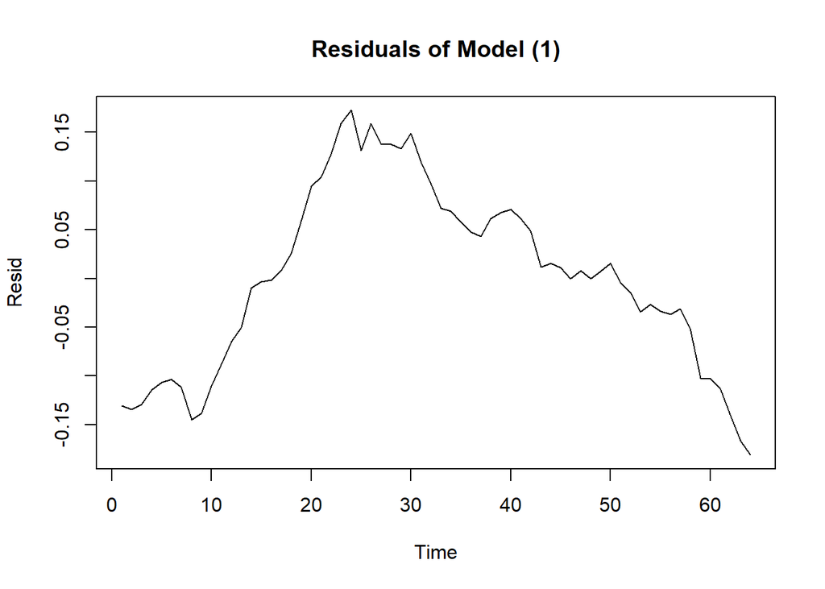

```
##
##  Two-step ADF test (with trend) on a single time series
##
## data: lnYO
## null hypothesis: Series has a unit root
## alternative hypothesis: Series is stationary
##
##      estimate largest root statistic p-value
## lnYO                 0.994   -0.2307  0.9907
```

```
## Progress: |------------------|
```

```
##
##  AWB bootstrap union test on a single time series
##
## data: lnYO
## null hypothesis: Series has a unit root
## alternative hypothesis: Series is stationary
##
##      estimate largest root statistic p-value
## lnYO                    NA   -0.3885  0.9565
```

The variable $lnYO_{t}$ has a unit root as shown by those two tests. The series has a stochastic process around the trend.

**Exports**

Consider the following model for $lnXO_{t}$:

$$\tag{2} lnXO_{t} = \beta_{0} + \beta_{1} t + u_{t}$$

```
##
## Call:
## lm(formula = lnXO_0 ~ trend)
##
## Residuals:
##      Min       1Q   Median       3Q      Max
## -0.30286 -0.09818  0.00590  0.07740  0.33393
##
## Coefficients:
##             Estimate Std. Error t value Pr(>|t|)
## (Intercept) 9.584272   0.037487  255.67   <2e-16 ***
## trend       0.052655   0.001003   52.51   <2e-16 ***
## ---
## Signif. codes:  0 '***' 0.001 '**' 0.01 '*' 0.05 '.' 0.1 ' ' 1
##
## Residual standard error: 0.1482 on 62 degrees of freedom
## Multiple R-squared:  0.978,  Adjusted R-squared:  0.9777
## F-statistic:  2757 on 1 and 62 DF,  p-value: < 2.2e-16
```

The average trend of $lnXO_{t}$ is $0.052655$ and it is statistically significant.

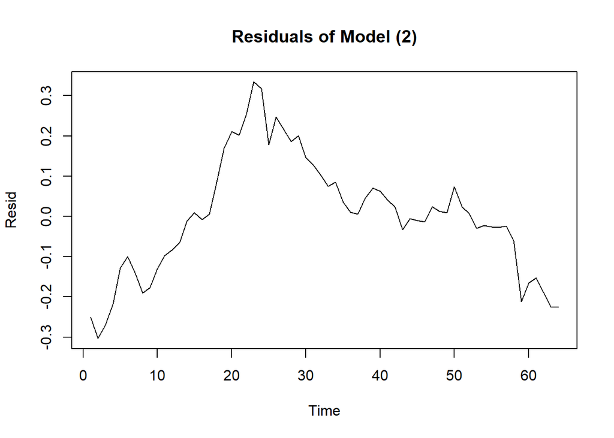

```
##
##  Two-step ADF test (with trend) on a single time series
##
## data: lnXO
## null hypothesis: Series has a unit root
## alternative hypothesis: Series is stationary
##
##      estimate largest root statistic p-value
## lnXO                0.9255    -1.919  0.6309
```

```
## Progress: |------------------|
```

```
##
##  AWB bootstrap union test on a single time series
##
## data: lnXO
## null hypothesis: Series has a unit root
## alternative hypothesis: Series is stationary
##
##      estimate largest root statistic p-value
## lnXO                    NA   -0.5432  0.8029
```

Once again, the two test show that $lnXO_{t}$ has a stochastic trend.

**Stationarity - Difference**

**Output**

Consider the first difference of $lnYO_{t}$:

$$\Delta lnYO_{t}$$

```
## Progress: |------------------|
```

```
##
##  AWB bootstrap union test on a single time series
##
## data: dlnYO
## null hypothesis: Series has a unit root
## alternative hypothesis: Series is stationary
##
##       estimate largest root statistic p-value
## dlnYO                    NA     -1.07 0.08004
```

```
## Progress: |------------------|
```

```
##
##  AWB bootstrap union test on a single time series
##
## data: d2lnYO
## null hypothesis: Series has a unit root
## alternative hypothesis: Series is stationary
##
##        estimate largest root statistic p-value
## d2lnYO                    NA    -4.942       0
```

The test tells us that $lnYO_{t}$ in first differences is also not stationary. But it is stationary in second differences. The problem is that the variable has no practical economic interpretation in second difference and thus we will stick with $dlnYO_{t}$ as our “stationary” dependent variable.

**Export**

Consider the first difference of $lnXO_{t}$:

$$\Delta lnXO_{t}$$

```
## Progress: |------------------|
```

```
##
##  AWB bootstrap union test on a single time series
##
## data: dlnXO
## null hypothesis: Series has a unit root
## alternative hypothesis: Series is stationary
##
##       estimate largest root statistic p-value
## dlnXO                    NA    -2.431       0
```

The first difference of $lnXO_{t}$ is already stationary.

## Regression Analysis

**Model 3**

Consider the following static regression model:

$$\tag{3} \Delta lnYO_{t} = \beta_{0} + \beta_{1} \Delta lnXO_{t} +
u_{t}$$

```
##
## Call:
## lm(formula = dlnYO_0 ~ dlnXO_0)
##
## Residuals:
##       Min        1Q    Median        3Q       Max
## -0.023032 -0.007787 -0.001477  0.006546  0.035424
##
## Coefficients:
##             Estimate Std. Error t value Pr(>|t|)
## (Intercept) 0.008908   0.002258   3.946 0.000208 ***
## dlnXO_0     0.339613   0.032244  10.533 2.36e-15 ***
## ---
## Signif. codes:  0 '***' 0.001 '**' 0.01 '*' 0.05 '.' 0.1 ' ' 1
##
## Residual standard error: 0.0117 on 61 degrees of freedom
## Multiple R-squared:  0.6452, Adjusted R-squared:  0.6394
## F-statistic: 110.9 on 1 and 61 DF,  p-value: 2.358e-15
```

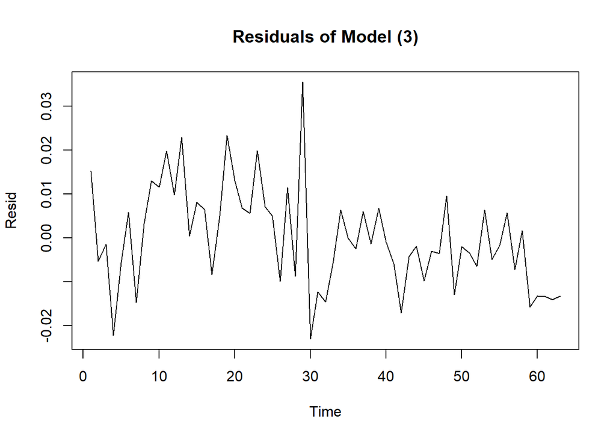

**Breusch-Pagan test**

```
##
##  studentized Breusch-Pagan test
##
## data:  model3
## BP = 0.052902, df = 1, p-value = 0.8181
```

**White Test**

```
##
##  studentized Breusch-Pagan test
##
## data:  model3
## BP = 0.052967, df = 2, p-value = 0.9739
```

We cannot reject the null hypothesis for both test meaning the residuals are homoskedastic.

**Model 4**

Consider the following ARDL(1,0) model:

$$\tag{4} \Delta lnYO_{t} = \beta_{0} + \beta_{1} \Delta lnXO_{t} +
\beta_{2} \Delta lnYO_{t - 1}$$

```
##
## Call:
## lm(formula = dlnYO_0 ~ dlnXO_0 + dlnYO_1)
##
## Residuals:
##       Min        1Q    Median        3Q       Max
## -0.026814 -0.007171 -0.000305  0.006211  0.035569
##
## Coefficients:
##             Estimate Std. Error t value Pr(>|t|)
## (Intercept) 0.003819   0.002754   1.387  0.17060
## dlnXO_0     0.326071   0.030777  10.595 2.29e-15 ***
## dlnYO_1     0.212764   0.072937   2.917  0.00496 **
## ---
## Signif. codes:  0 '***' 0.001 '**' 0.01 '*' 0.05 '.' 0.1 ' ' 1
##
## Residual standard error: 0.01104 on 60 degrees of freedom
## Multiple R-squared:  0.6893, Adjusted R-squared:  0.6789
## F-statistic: 66.55 on 2 and 60 DF,  p-value: 5.898e-16
```

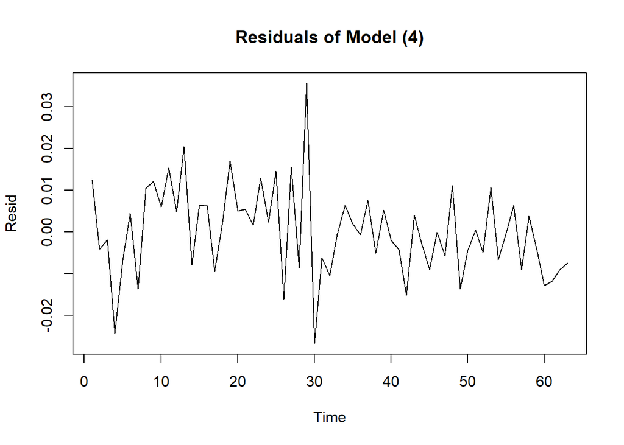

**Breusch-Pagan Test**

```
##
##  studentized Breusch-Pagan test
##
## data:  model4
## BP = 0.84664, df = 2, p-value = 0.6549
```

**White Test**

```
##
##  studentized Breusch-Pagan test
##
## data:  model4
## BP = 0.91435, df = 5, p-value = 0.9692
```

Once again, both tests tell us that the residuals are homoskedastic.

**Correlogram**

**Output**

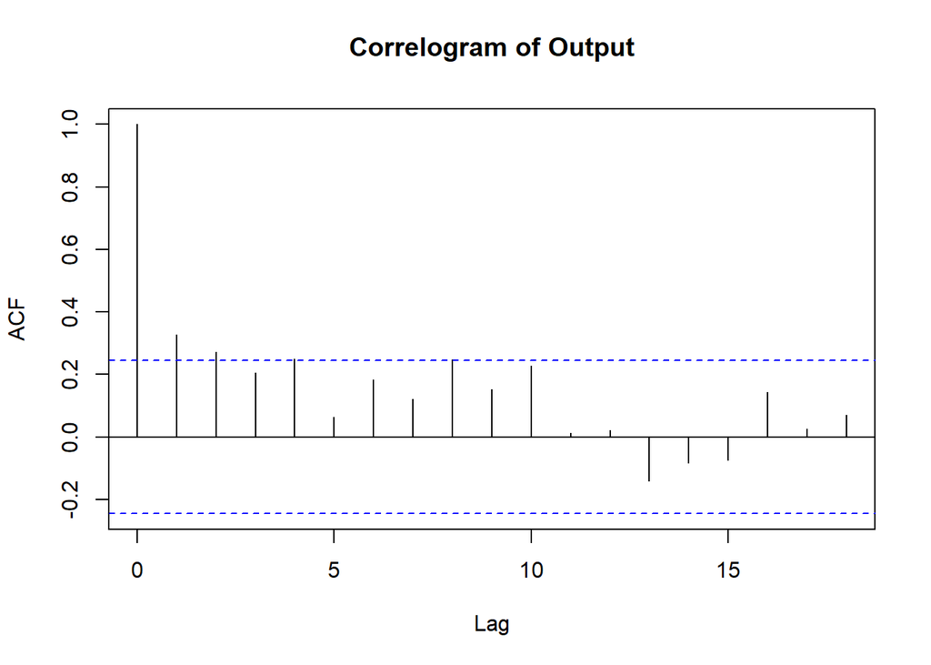

The first and second lags are significant and should probably be added to the next model to remove autocorrelation.

**Exports**

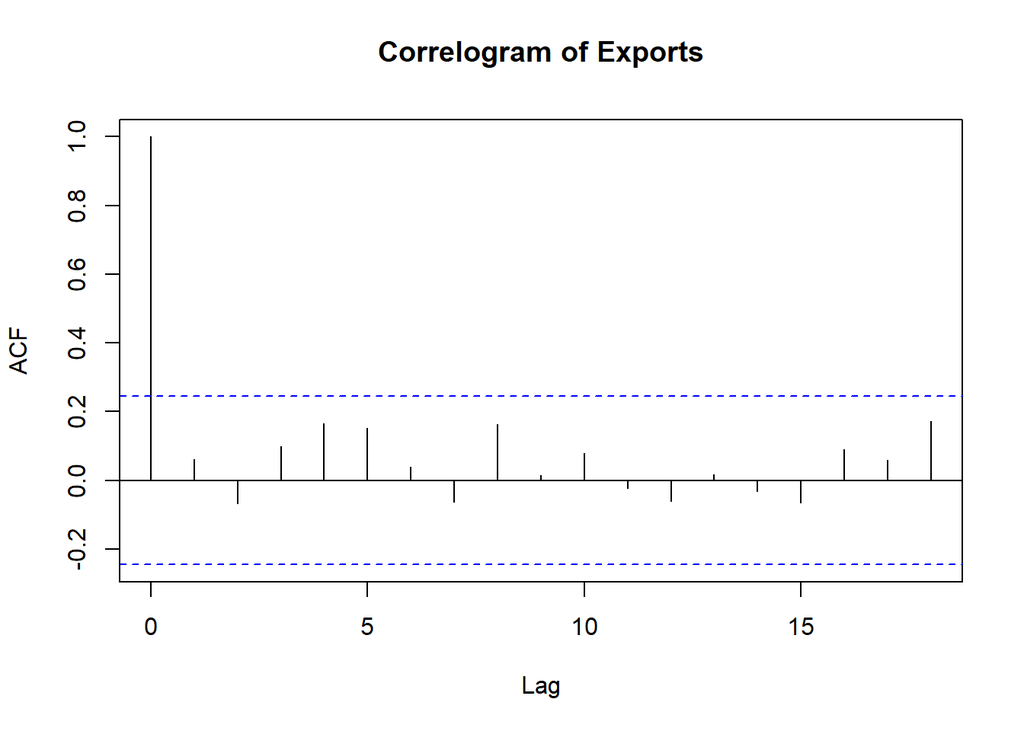

There is no autocorrelation left in the $dlnXO_{t}$ series. We do not need to add any lags.

**Model 5**

Consider the following ARDL(2,0) model:

$$\tag{5} \Delta lnYO_{t} = \beta_{0} + \beta_{1} \Delta lnXO_{t} +
\beta_{2} \Delta lnYO_{t - 1} + \Delta \beta_{3} lnYO_{t - 2}$$

**Variables**

```
##
## Call:
## lm(formula = dlnYO2_0 ~ dlnXO2_0 + dlnYO2_1 + dlnYO2_2)
##
## Residuals:
##       Min        1Q    Median        3Q       Max
## -0.024921 -0.004623 -0.000769  0.006146  0.035963
##
## Coefficients:
##              Estimate Std. Error t value Pr(>|t|)
## (Intercept) -0.001317   0.002922  -0.451  0.65380
## dlnXO2_0     0.336955   0.028722  11.731  < 2e-16 ***
## dlnYO2_1     0.127959   0.071183   1.798  0.07745 .
## dlnYO2_2     0.239853   0.071244   3.367  0.00136 **
## ---
## Signif. codes:  0 '***' 0.001 '**' 0.01 '*' 0.05 '.' 0.1 ' ' 1
##
## Residual standard error: 0.01016 on 58 degrees of freedom
## Multiple R-squared:  0.7457, Adjusted R-squared:  0.7325
## F-statistic: 56.69 on 3 and 58 DF,  p-value: < 2.2e-16
```

**Linear Hypothesis Test**

```
## Linear hypothesis test
##
## Hypothesis:
## dlnXO2_0 = 0
## dlnYO2_1 = 0
## dlnYO2_2 = 0
##
## Model 1: restricted model
## Model 2: dlnYO2_0 ~ dlnXO2_0 + dlnYO2_1 + dlnYO2_2
##
## Note: Coefficient covariance matrix supplied.
##
##   Res.Df Df      F    Pr(>F)
## 1     61
## 2     58  3 45.286 3.292e-15 ***
## ---
## Signif. codes:  0 '***' 0.001 '**' 0.01 '*' 0.05 '.' 0.1 ' ' 1
```

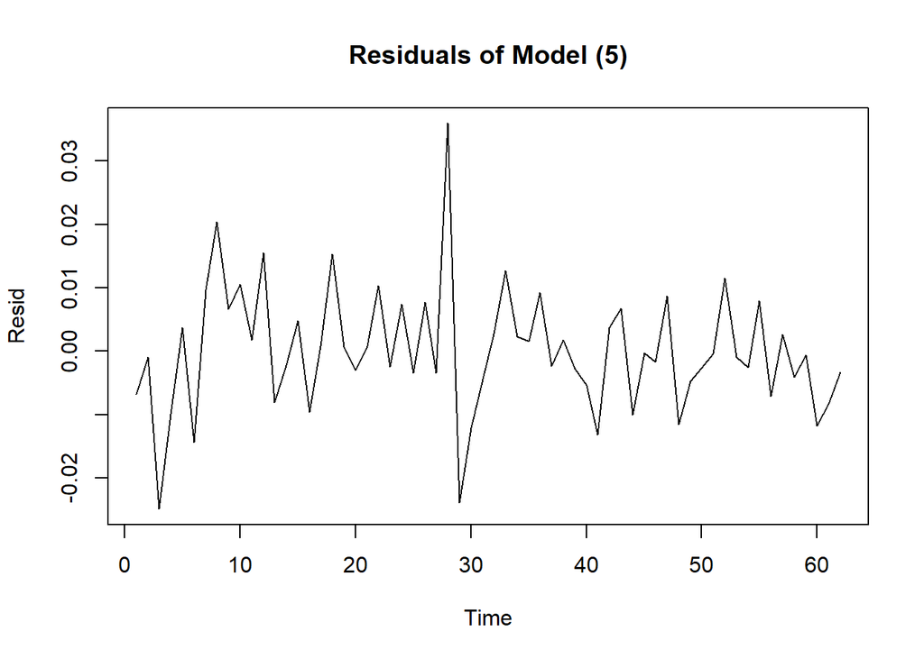

**Breusch-Pagan Test**

```
##
##  studentized Breusch-Pagan test
##
## data:  model5
## BP = 0.45614, df = 3, p-value = 0.9284
```

**White Test**

```
##
##  studentized Breusch-Pagan test
##
## data:  model5
## BP = 3.0524, df = 9, p-value = 0.9622
```

Again the tests tell us that the residuals are homoskedastic. There is still some structure left to be explained by the model.

**Autocorrelation Problem**

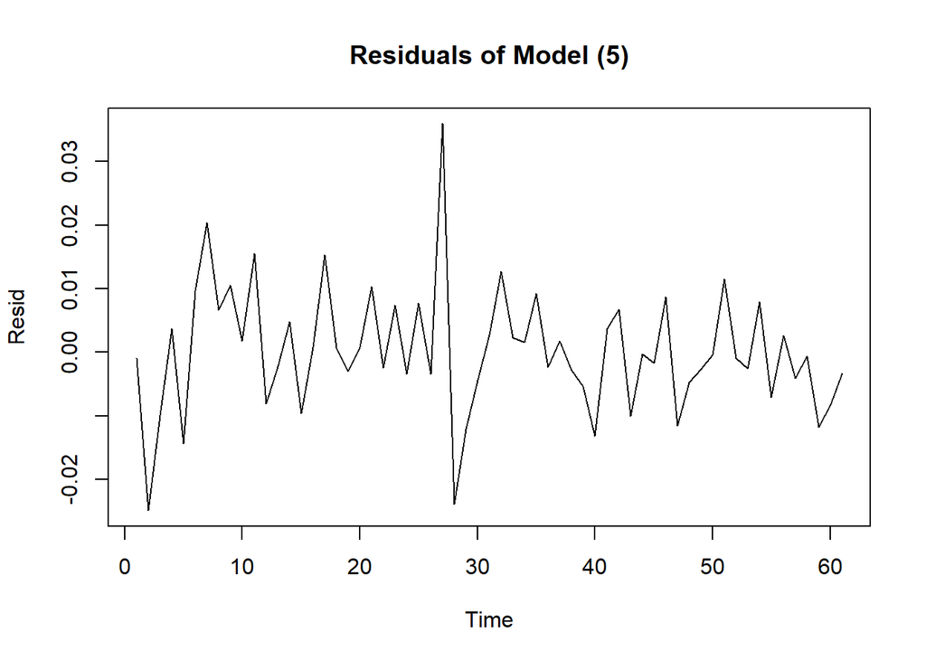

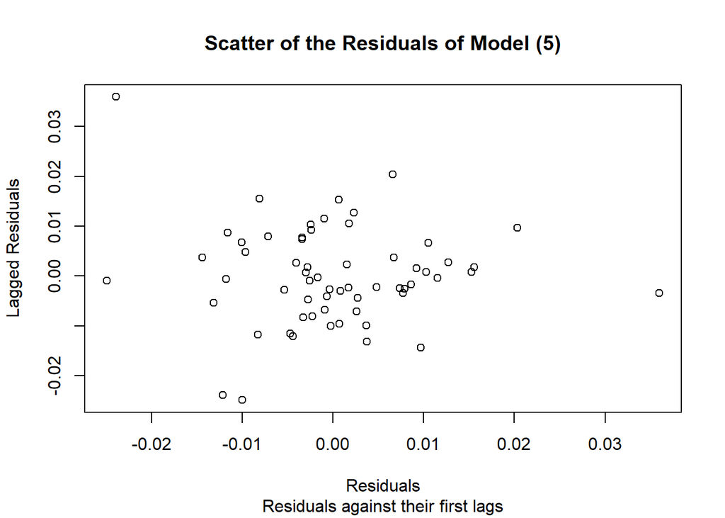

There does not seem to be a high level of autocorrelation even despite not including all the lags.

**Ljung-Box Test**

```
##
##  Box-Ljung test
##
## data:  model5$residuals
## X-squared = 2.3795, df = 4, p-value = 0.6663
```

```
##
## Call:
## lm(formula = ut5_0 ~ ut5_1)
##
## Residuals:
##       Min        1Q    Median        3Q       Max
## -0.025098 -0.005334 -0.001032  0.006863  0.035615
##
## Coefficients:
##               Estimate Std. Error t value Pr(>|t|)
## (Intercept)  0.0001151  0.0012812   0.090    0.929
## ut5_1       -0.0680145  0.1294937  -0.525    0.601
##
## Residual standard error: 0.01001 on 59 degrees of freedom
## Multiple R-squared:  0.004654,   Adjusted R-squared:  -0.01222
## F-statistic: 0.2759 on 1 and 59 DF,  p-value: 0.6014
```

The p-value of $\beta_{1}$ is not significant meaning that there might be no first-order autocorrelation.

**Breusch-Godfrey Test**

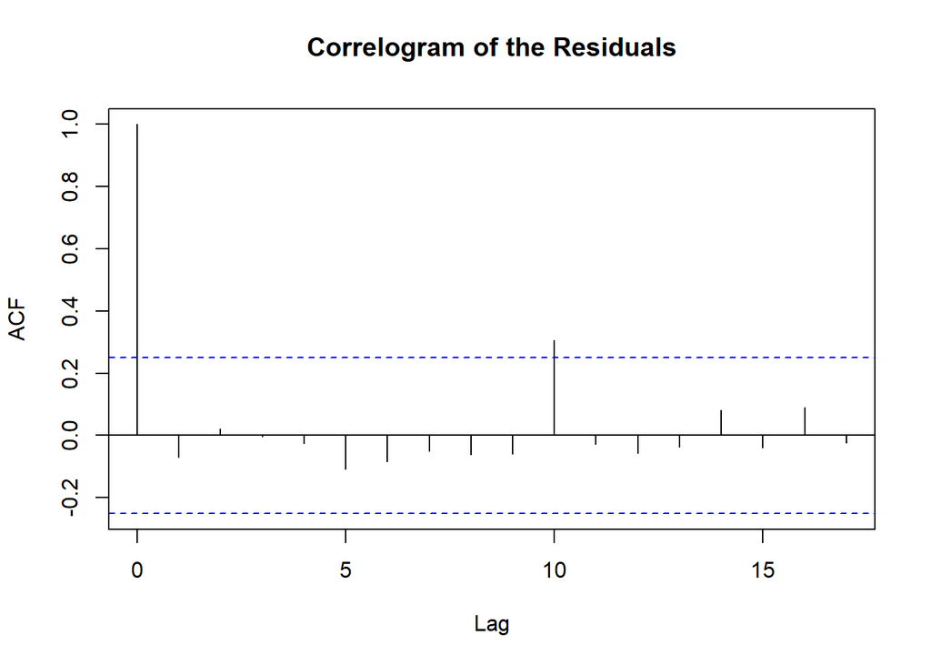

```
##
##  Breusch-Godfrey test for serial correlation of order up to 3
##
## data:  model5
## LM test = 0.61497, df = 3, p-value = 0.893
```

According to the BG test, the residuals have no serial correlation since the p-value was too high to reject the null.

**RESET Test**

```
##
##  RESET test
##
## data:  model5
## RESET = 1.3156, df1 = 2, df2 = 56, p-value = 0.2765
```

The p-value is above the 5% significance level meaning that we cannot reject the null hypothesis of Correct specification.

**Model 6**

Consider the following Vector AutoRegressive Model:

**Augmented Dickey-Fuller**

```
##
##  Two-step ADF test (with intercept) on a single time series
##
## data: dlnYO
## null hypothesis: Series has a unit root
## alternative hypothesis: Series is stationary
##
##       estimate largest root statistic   p-value
## dlnYO                0.3292    -5.627 1.066e-05
```

```
##
##  Two-step ADF test (with intercept) on a single time series
##
## data: dlnXO
## null hypothesis: Series has a unit root
## alternative hypothesis: Series is stationary
##
##       estimate largest root statistic   p-value
## dlnXO               0.06224    -7.865 3.859e-09
```

The low p-values of both tests indicate that both variables are likely stationary.

**Estimate VAR**

```
## $selection
## AIC(n)  HQ(n)  SC(n) FPE(n)
##      2      2      2      2
##
## $criteria
##                    1             2             3             4             5
## AIC(n) -1.511882e+01 -1.536408e+01 -1.524173e+01 -1.513811e+01 -1.512692e+01
## HQ(n)  -1.503359e+01 -1.522203e+01 -1.504286e+01 -1.488242e+01 -1.481441e+01
## SC(n)  -1.489782e+01 -1.499575e+01 -1.472607e+01 -1.447512e+01 -1.431659e+01
## FPE(n)  2.716943e-07  2.127784e-07  2.409201e-07  2.681195e-07  2.725736e-07
##                    6             7             8             9            10
## AIC(n) -1.500953e+01 -1.503530e+01 -1.497950e+01 -1.496380e+01 -1.493828e+01
## HQ(n)  -1.464020e+01 -1.460915e+01 -1.449653e+01 -1.442400e+01 -1.434167e+01
## SC(n)  -1.405187e+01 -1.393031e+01 -1.372718e+01 -1.356414e+01 -1.339129e+01
## FPE(n)  3.088990e-07  3.042788e-07  3.263700e-07  3.377431e-07  3.547427e-07
```

The order given by the output is 2. It is the same for all Information Criteria.

```
##
## VAR Estimation Results:
## =========================
## Endogenous variables: dlnYO, dlnXO
## Deterministic variables: const
## Sample size: 62
## Log Likelihood: 304.455
## Roots of the characteristic polynomial:
## 0.6949 0.5363 0.374 0.374
## Call:
## VAR(y = VAR6_data, p = 2)
##
##
## Estimation results for equation dlnYO:
## ======================================
## dlnYO = dlnYO.l1 + dlnXO.l1 + dlnYO.l2 + dlnXO.l2 + const
##
##           Estimate Std. Error t value Pr(>|t|)
## dlnYO.l1  0.235984   0.219054   1.077  0.28589
## dlnXO.l1  0.016606   0.088796   0.187  0.85231
## dlnYO.l2  0.391162   0.201743   1.939  0.05747 .
## dlnXO.l2 -0.096844   0.078712  -1.230  0.22361
## const     0.014223   0.004793   2.967  0.00439 **
## ---
## Signif. codes:  0 '***' 0.001 '**' 0.01 '*' 0.05 '.' 0.1 ' ' 1
##
##
## Residual standard error: 0.01855 on 57 degrees of freedom
## Multiple R-Squared: 0.1662,  Adjusted R-squared: 0.1077
## F-statistic: 2.841 on 4 and 57 DF,  p-value: 0.03226
##
##
## Estimation results for equation dlnXO:
## ======================================
## dlnXO = dlnYO.l1 + dlnXO.l1 + dlnYO.l2 + dlnXO.l2 + const
##
##          Estimate Std. Error t value Pr(>|t|)
## dlnYO.l1  0.57356    0.54858   1.046 0.300193
## dlnXO.l1 -0.07636    0.22237  -0.343 0.732573
## dlnYO.l2  0.21333    0.50523   0.422 0.674429
## dlnXO.l2 -0.18606    0.19712  -0.944 0.349203
## const     0.04682    0.01200   3.900 0.000256 ***
## ---
## Signif. codes:  0 '***' 0.001 '**' 0.01 '*' 0.05 '.' 0.1 ' ' 1
##
##
## Residual standard error: 0.04645 on 57 degrees of freedom
## Multiple R-Squared: 0.04486, Adjusted R-squared: -0.02216
## F-statistic: 0.6693 on 4 and 57 DF,  p-value: 0.6159
##
##
##
## Covariance matrix of residuals:
##           dlnYO     dlnXO
## dlnYO 0.0003441 0.0007227
## dlnXO 0.0007227 0.0021580
##
## Correlation matrix of residuals:
##        dlnYO  dlnXO
## dlnYO 1.0000 0.8387
## dlnXO 0.8387 1.0000
```

All the variables (other than the constant) are insignificant at the 5% level.

**Residual analysis**

[figure not shown]

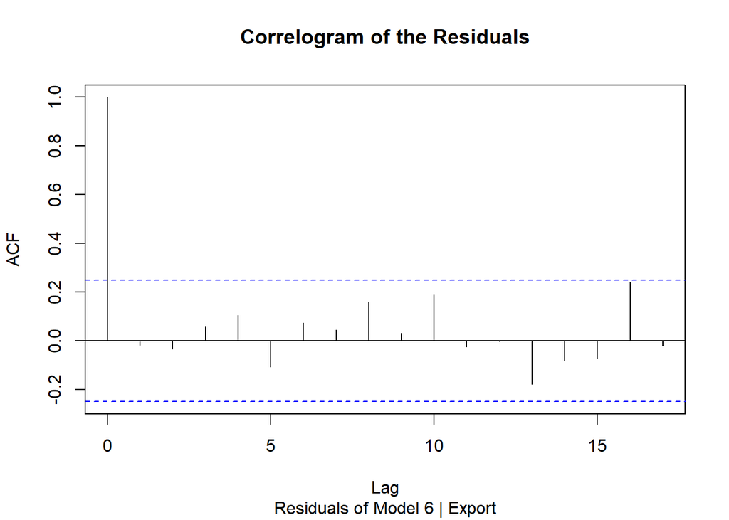

[figure not shown]

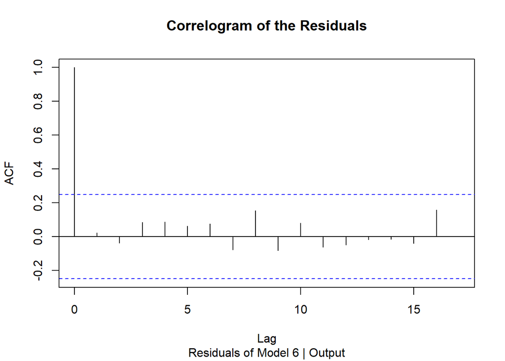

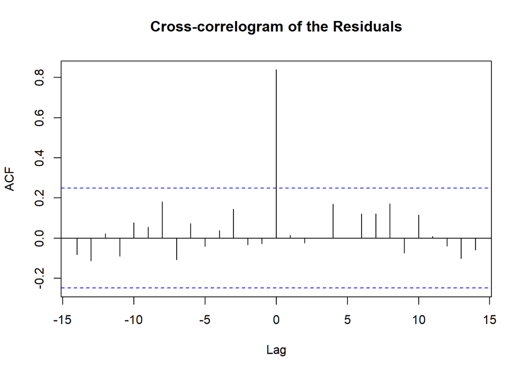

**Granger Causality**

```
##
##  Granger causality H0: dlnYO do not Granger-cause dlnXO
##
## data:  VAR object model6
## F-Test = 0.7104, df1 = 2, df2 = 114, p-value = 0.4936
```

```
##
##  Granger causality H0: dlnXO do not Granger-cause dlnYO
##
## data:  VAR object model6
## F-Test = 0.82106, df1 = 2, df2 = 114, p-value = 0.4426
```

**Impulse Response Functions**

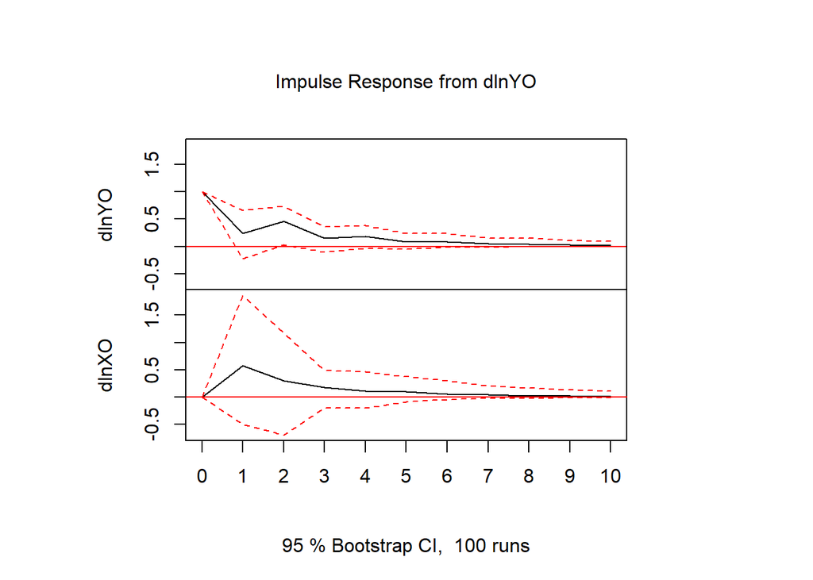

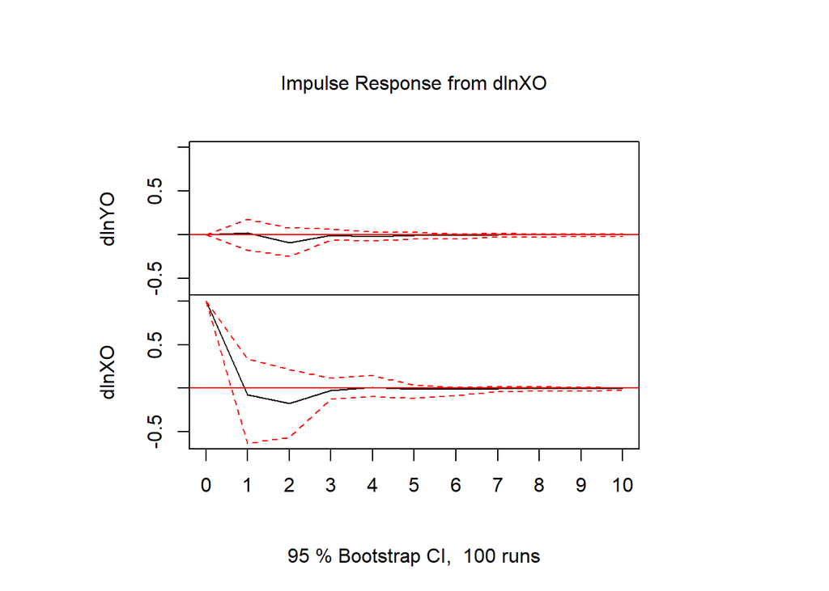

**Model 7**

There seems to be an omitted variable bias in the previous regressions that I estimated. For this reason I might follow the same path we followed in class and estimate a regression of export on income.And since we already that the first and second lags of $lnYO_{t}$ were significant we can already include them in our model.

$$\tag{7} \Delta lnXO_{t} = \beta_{0} + \beta_{1} \Delta lnYO_{t} +
\beta_{2} \Delta lnYO_{t - 1} + \beta_{3} \Delta lnYO_{t - 2}$$

```
##
## Call:
## lm(formula = dlnXO2_0 ~ dlnYO2_0 + dlnYO2_1 + dlnYO2_2)
##
## Residuals:
##       Min        1Q    Median        3Q       Max
## -0.090997 -0.012611 -0.000402  0.014324  0.076326
##
## Coefficients:
##              Estimate Std. Error t value Pr(>|t|)
## (Intercept)  0.016422   0.006959   2.360  0.02167 *
## dlnYO2_0     2.087868   0.177972  11.731  < 2e-16 ***
## dlnYO2_1    -0.141720   0.181106  -0.783  0.43709
## dlnYO2_2    -0.540340   0.180451  -2.994  0.00404 **
## ---
## Signif. codes:  0 '***' 0.001 '**' 0.01 '*' 0.05 '.' 0.1 ' ' 1
##
## Residual standard error: 0.02528 on 58 degrees of freedom
## Multiple R-squared:  0.7122, Adjusted R-squared:  0.6973
## F-statistic: 47.83 on 3 and 58 DF,  p-value: 1.081e-15
```

According to the output of model 7, only the coefficient of the first lag of dlnYO is insignificant.

```
## Linear hypothesis test
##
## Hypothesis:
## dlnYO2_1 = 0
## dlnYO2_2 = 0
##
## Model 1: restricted model
## Model 2: dlnXO2_0 ~ dlnYO2_0 + dlnYO2_1 + dlnYO2_2
##
##   Res.Df      RSS Df Sum of Sq      F   Pr(>F)
## 1     60 0.044403
## 2     58 0.037068  2 0.0073347 5.7382 0.005323 **
## ---
## Signif. codes:  0 '***' 0.001 '**' 0.01 '*' 0.05 '.' 0.1 ' ' 1
```

The p-value of the F-test is too low $0.005323$ and thus we can reject the null. At least one of the two variables is significantly different from 0.

```
## Linear hypothesis test
##
## Hypothesis:
## dlnYO2_0 = 0
## dlnYO2_1 = 0
## dlnYO2_2 = 0
##
## Model 1: restricted model
## Model 2: dlnXO2_0 ~ dlnYO2_0 + dlnYO2_1 + dlnYO2_2
##
##   Res.Df      RSS Df Sum of Sq      F    Pr(>F)
## 1     61 0.128781
## 2     58 0.037068  3  0.091713 47.834 1.081e-15 ***
## ---
## Signif. codes:  0 '***' 0.001 '**' 0.01 '*' 0.05 '.' 0.1 ' ' 1
```

**Residual analysis**

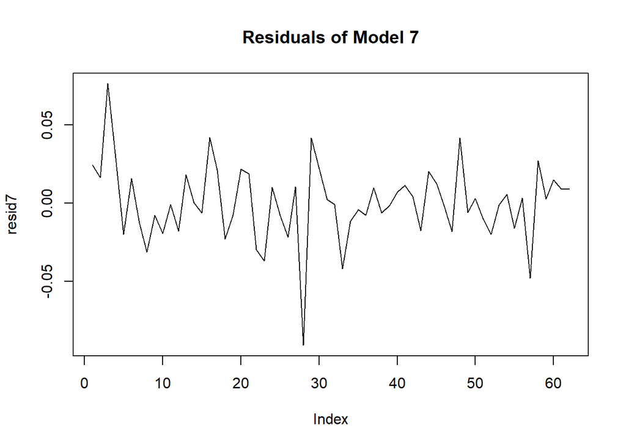

Now we need to check whether the residuals are heteroscedastic meaning that we have remove all the structure from the residuals and completely modeled the relation. This is done with a White test.

```
##
##  studentized Breusch-Pagan test
##
## data:  model7
## BP = 3.6072, df = 5, p-value = 0.6072
```

**Model 8**

$$\tag{8} \Delta lnXO_{t} = \beta_{0} + \beta_{1} \Delta lnYO_{t}$$

```
##
## Call:
## lm(formula = dlnXO ~ dlnYO)
##
## Residuals:
##       Min        1Q    Median        3Q       Max
## -0.089011 -0.014727  0.001664  0.015947  0.102307
##
## Coefficients:
##             Estimate Std. Error t value Pr(>|t|)
## (Intercept) 0.002346   0.006571   0.357    0.722
## dlnYO       1.943378   0.197904   9.820    3e-14 ***
## ---
## Signif. codes:  0 '***' 0.001 '**' 0.01 '*' 0.05 '.' 0.1 ' ' 1
##
## Residual standard error: 0.03042 on 62 degrees of freedom
## Multiple R-squared:  0.6087, Adjusted R-squared:  0.6023
## F-statistic: 96.43 on 1 and 62 DF,  p-value: 2.998e-14
```

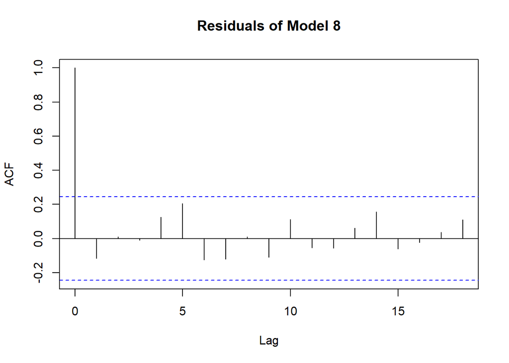

## Introducing a new variable

If we estimate model 8 to reduce the omitted variable bias problem that we had in the previous models. We might find it valuable to add a second variable, namely the exchange rate since we know from economic theory that exports positively depend on the exchange rate. An exchange rate decrease (currency appreciation leads to fewer exports as local goods become more expensive to foreign consumers).

In this section, we will investigate the relationship between exports as the dependent variable and output and exchange rates as the independent variables.

**Exchange rates**

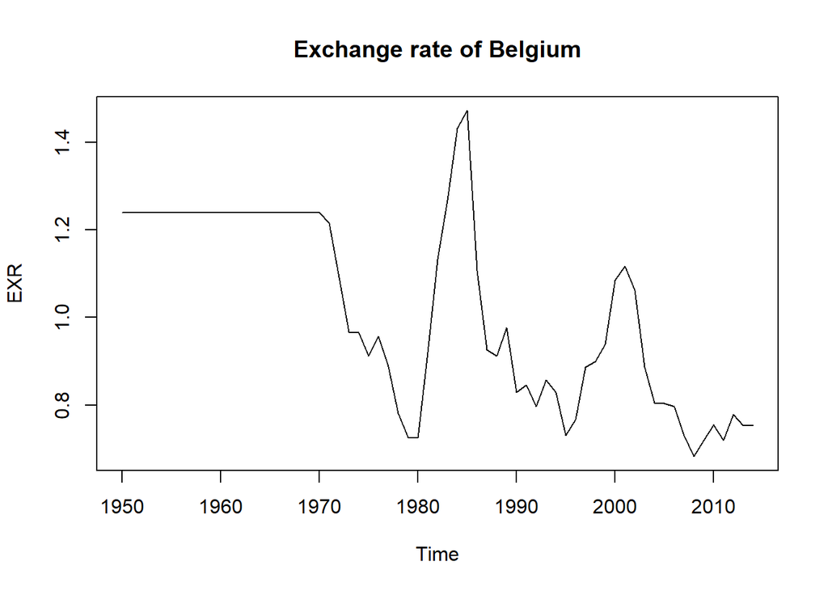

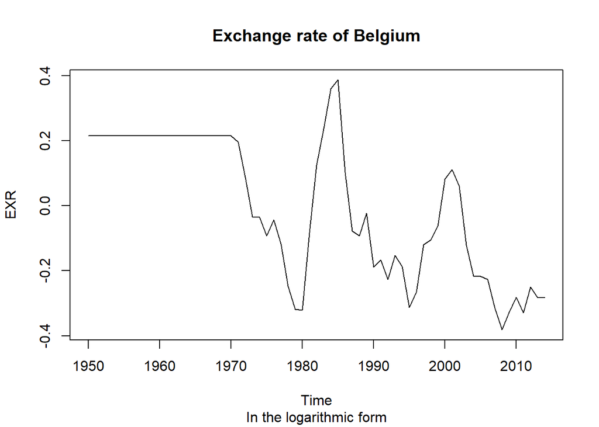

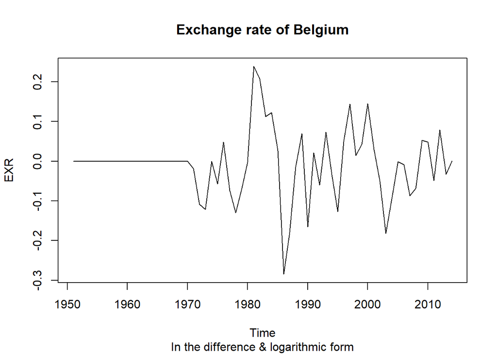

Belgium seems to have had a fixed exchange rate regime from 1950 to 1970. This leads me to fear that the stationary condition might not be met by this variable neither in the logarithmic nor the difference form. I will proceed with both and Augmented Dickey-Fuller and a union of rejection test on $lnEXR_{t}$ and $\Delta lnEXR_{t}$. There seems to be a small downward trend.

```
## Progress: |------------------|
```

```
##
##  AWB bootstrap union test on a single time series
##
## data: lnEXR
## null hypothesis: Series has a unit root
## alternative hypothesis: Series is stationary
##
##       estimate largest root statistic p-value
## lnEXR                    NA    -1.071 0.05803
```

```
##
##  Two-step ADF test (with trend) on a single time series
##
## data: lnEXR
## null hypothesis: Series has a unit root
## alternative hypothesis: Series is stationary
##
##       estimate largest root statistic p-value
## lnEXR                0.8097    -2.606  0.2794
```

The p-value in the union of rejection test is above the 5% significance level meaning that there might be a unit root in this time series. This is confirmed by the Augmented Dickey-Fuller.

```
## Progress: |------------------|
```

```
##
##  AWB bootstrap union test on a single time series
##
## data: dlnEXR
## null hypothesis: Series has a unit root
## alternative hypothesis: Series is stationary
##
##        estimate largest root statistic p-value
## dlnEXR                    NA    -2.297       0
```

```
##
##  Two-step ADF test (with intercept) on a single time series
##
## data: dlnEXR
## null hypothesis: Series has a unit root
## alternative hypothesis: Series is stationary
##
##        estimate largest root statistic  p-value
## dlnEXR                0.3694    -5.386 2.52e-05
```

The p-value of both test allows us to conclude that this series is stationary in difference and logarithmic form.

**Model 9**

Now let’s consider the following model:

$$\tag{9} \Delta lnXO_{t} = \beta_{0} + \beta_{1} \Delta lnYO_{t} +
\beta_{4} \Delta lnEXR_{t}$$

```
##
## Call:
## lm(formula = dlnXO ~ dlnYO + dlnEXR)
##
## Residuals:
##       Min        1Q    Median        3Q       Max
## -0.090079 -0.014954  0.004402  0.014857  0.101339
##
## Coefficients:
##             Estimate Std. Error t value Pr(>|t|)
## (Intercept) 0.001822   0.006479   0.281   0.7795
## dlnYO       1.984203   0.196370  10.104  1.2e-14 ***
## dlnEXR      0.074804   0.043782   1.709   0.0926 .
## ---
## Signif. codes:  0 '***' 0.001 '**' 0.01 '*' 0.05 '.' 0.1 ' ' 1
##
## Residual standard error: 0.02996 on 61 degrees of freedom
## Multiple R-squared:  0.6265, Adjusted R-squared:  0.6143
## F-statistic: 51.17 on 2 and 61 DF,  p-value: 8.992e-14
```

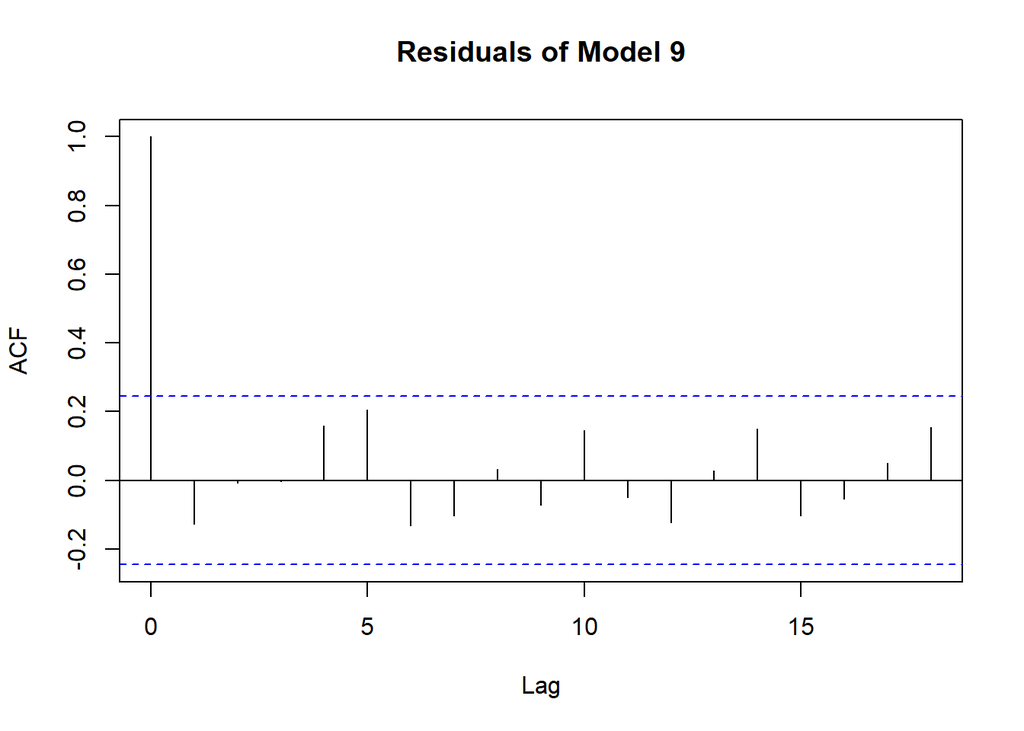

The exchange variable is found to be insignificant but this is probably simply due to the autocorrelation in that variable. The solution here might be to add a second lag.

**Model 10**

Consider then the following model which is similar to model (9) but we have added a lagged version of $\Delta lnEXR_{t}$.

$$\tag{10} \Delta lnXO_{t} = \beta_{0} + \beta_{1} \Delta lnYO_{t} +
\beta_{4} \Delta lnEXR_{t} + \beta_{5} \Delta lnEXR_{t - 1}$$

```
##
## Call:
## lm(formula = dlnXO_0 ~ dlnYO_0 + dlnEXR_0 + dlnEXR_1)
##
## Residuals:
##       Min        1Q    Median        3Q       Max
## -0.086607 -0.013129  0.006444  0.015538  0.072684
##
## Coefficients:
##             Estimate Std. Error t value Pr(>|t|)
## (Intercept) 0.001227   0.005927   0.207    0.837
## dlnYO_0     1.949369   0.180982  10.771 1.48e-15 ***
## dlnEXR_0    0.065105   0.042795   1.521    0.134
## dlnEXR_1    0.019242   0.043008   0.447    0.656
## ---
## Signif. codes:  0 '***' 0.001 '**' 0.01 '*' 0.05 '.' 0.1 ' ' 1
##
## Residual standard error: 0.02735 on 59 degrees of freedom
## Multiple R-squared:  0.6648, Adjusted R-squared:  0.6477
## F-statistic:    39 on 3 and 59 DF,  p-value: 5.075e-14
```

In this model, both version of the exchange rate are insignificant. This is annoying!

**Correlogram**

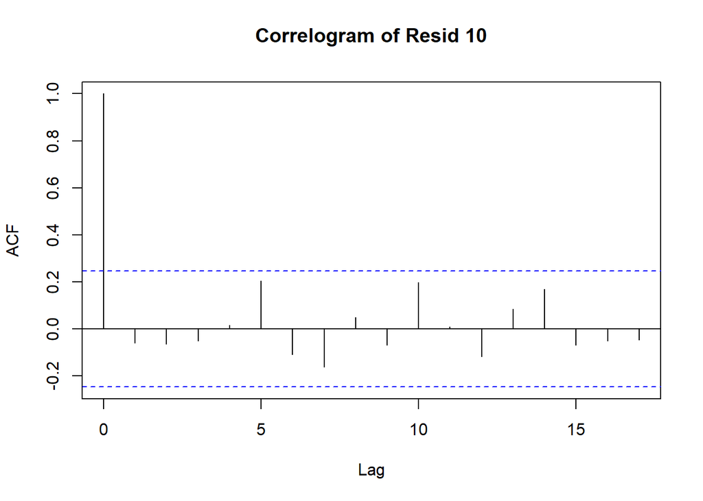

**Heteroscedasticity in residuals**

```
##
##  studentized Breusch-Pagan test
##
## data:  model10
## BP = 5.5258, df = 9, p-value = 0.7863
```

**Joint Significance**

We will test the following restrictions

$$\beta_{4} = 0 \\ \beta_{5} = 0$$

```
## Linear hypothesis test
##
## Hypothesis:
## dlnEXR_0 = 0
## dlnEXR_1 = 0
##
## Model 1: restricted model
## Model 2: dlnXO_0 ~ dlnYO_0 + dlnEXR_0 + dlnEXR_1
##
##   Res.Df      RSS Df Sum of Sq      F Pr(>F)
## 1     61 0.046703
## 2     59 0.044130  2 0.0025729 1.7199 0.1879
```

The high p-value of `0.1879` means that we cannot reject our null hypothesis. The two coefficient might be not significantly different from 0.

**Conclusion**

Model 9 and Model 10 teaches us that Model 8 might be the best model for the relation between Export and Output.

$$\tag{8} \Delta lnXO_{t} = \beta_{0} + \beta_{1} \Delta lnYO_{t}$$

Once again, to avoid omitted variable bias, I will choose this model over model (5).

We can also take a look at model (7).

$$\tag{7} \Delta lnXO_{t} = \beta_{0} + \beta_{1} \Delta lnYO_{t} +
\beta_{2} \Delta lnYO_{t - 1} + \beta_{3} \Delta lnYO_{t - 2}$$

## Cointegration

Since $lnYO_{t}$ and $lnXO_{t}$ are both $I(1)$ processes. There might exist a linear combination of the two that is $I(0)$.

The transformation looks like the following:

$$y_{t} - \beta_{1} x_{t} = u_{t}$$

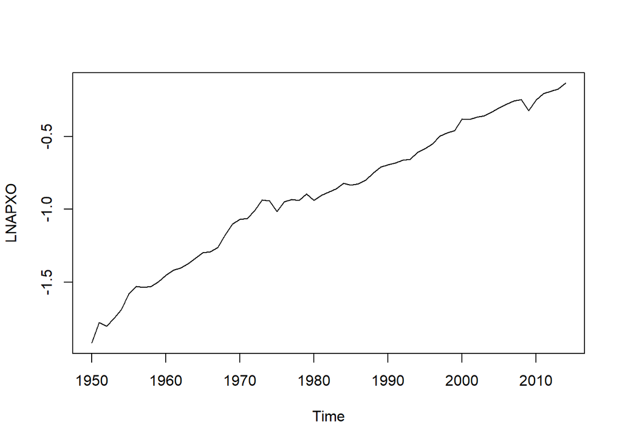

The export ratio does not seem to be stationary.

**Augmented Dickey-Fuller**

```
##
##  Two-step ADF test (with intercept) on a single time series
##
## data: LNAPXO
## null hypothesis: Series has a unit root
## alternative hypothesis: Series is stationary
##
##        estimate largest root statistic p-value
## LNAPXO                0.9786    -1.859  0.3495
```

We can concluded that the two variables are not cointegrated since `LNAPXO` is not stationary.

**Model (c)**

Consider the following regression:

$$\tag{c} lnXO_{t} = \beta_{0} + \beta_{1} lnYO_{t} + u_{t}$$

```
##
## Call:
## lm(formula = lnXO ~ lnYO)
##
## Residuals:
##       Min        1Q    Median        3Q       Max
## -0.134791 -0.052733  0.004992  0.041148  0.124635
##
## Coefficients:
##              Estimate Std. Error t value Pr(>|t|)
## (Intercept) -11.73450    0.16848  -69.65   <2e-16 ***
## lnYO          1.89245    0.01385  136.63   <2e-16 ***
## ---
## Signif. codes:  0 '***' 0.001 '**' 0.01 '*' 0.05 '.' 0.1 ' ' 1
##
## Residual standard error: 0.05945 on 63 degrees of freedom
## Multiple R-squared:  0.9966, Adjusted R-squared:  0.9966
## F-statistic: 1.867e+04 on 1 and 63 DF,  p-value: < 2.2e-16
```

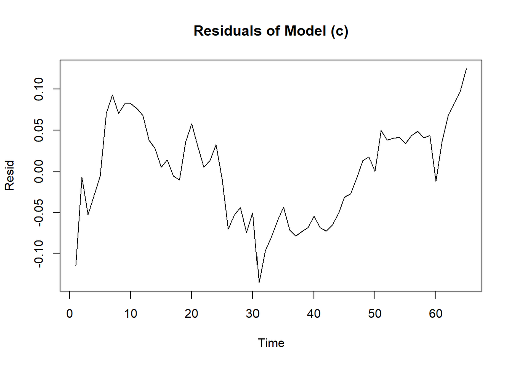

**Engle-Granger test**

```
##
##  Two-step ADF test (with none) on a single time series
##
## data: residc
## null hypothesis: Series has a unit root
## alternative hypothesis: Series is stationary
##
##        estimate largest root statistic p-value
## residc                0.8654    -2.097 0.03549
```

The p-value is lower than the significance level implying that we do have cointegration between $lnXO_{t}$ and $lnYO_{t}$.

**Model 11**

Consider the following model:

$$\tag{11} \Delta lnXO_{t} = \beta_{0} + \beta_{1} \Delta lnYO_{t} +
\beta_{4} \Delta lnEXR_{t} + u_{t}$$

[output not shown]